# Classification

Jeu de données res.CA

.

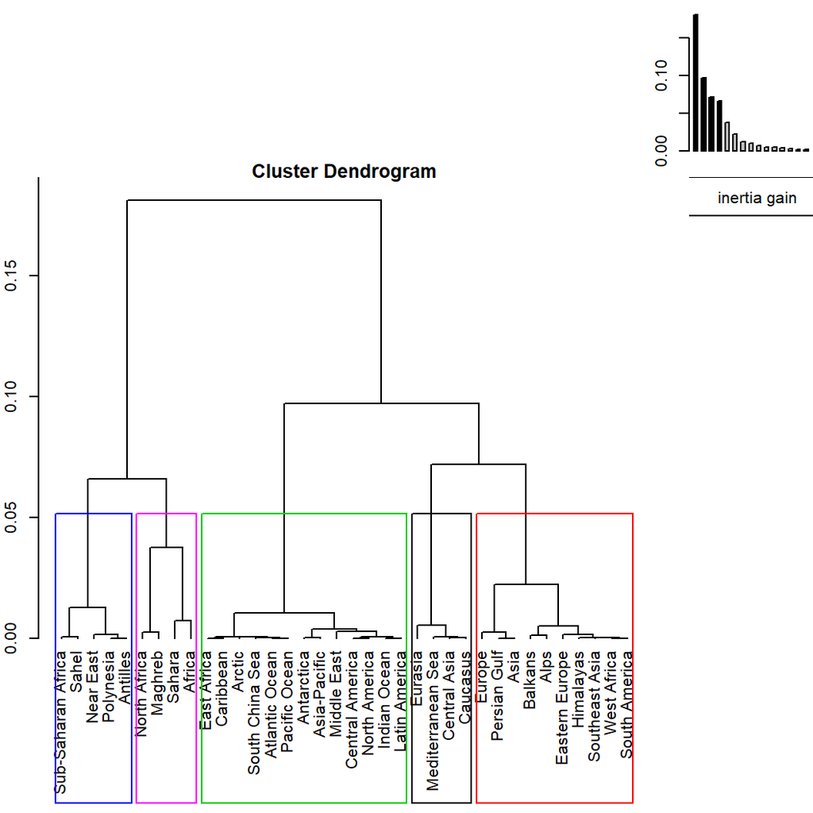

**Figure 1.1 - Arbre hiérarchique.**

La classification réalisée sur les individus fait apparaître 5 classes.

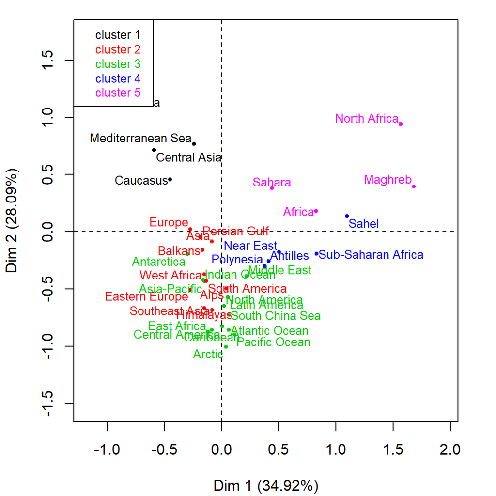

**Figure 1.2 - Classification Ascendante Hiérachique des individus.**

La **classe 1** est composée d’individus tels que *Eurasia* et *Mediterranean Sea*. Ce groupe est caractérisé par :

- des variables dont les valeurs ne diffèrent pas significativement de la moyenne.

La **classe 2** est composée d’individus tels que *Europe*. Ce groupe est caractérisé par :

- des variables dont les valeurs ne diffèrent pas significativement de la moyenne.

La **classe 3** est composée d’individus tels que *Caribbean*, *Arctic*, *Atlantic Ocean*, *Pacific Ocean* et *Middle East*. Ce groupe est caractérisé par :

- des variables dont les valeurs ne diffèrent pas significativement de la moyenne.

La **classe 4** est composée d’individus tels que *Sahel*. Ce groupe est caractérisé par :

- des variables dont les valeurs ne diffèrent pas significativement de la moyenne.

La **classe 5** est composée d’individus tels que *Africa*, *North Africa* et *Maghreb*. Ce groupe est caractérisé par :

- des variables dont les valeurs ne diffèrent pas significativement de la moyenne.

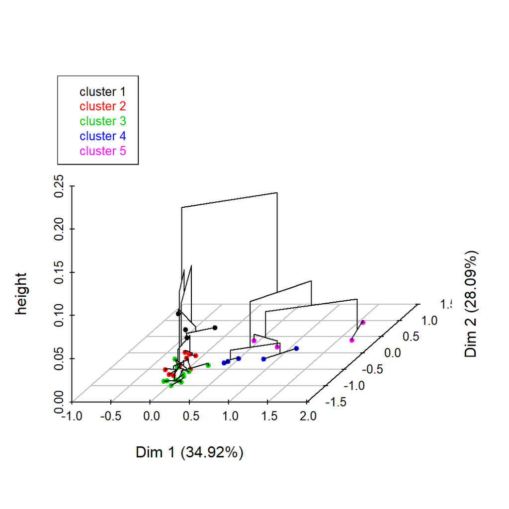

**Figure 1.3 - Arbre hiérarchique sur le plan factoriel.**

The hierarchical tree can be drawn on the factorial map with the individuals colored according to their clusters.